# Weather

Weather data management and interpolation

This module handles weather data for fire simulations, including spatially and temporally varying conditions.

```julia
using Elmfire
using Plots
```

## Types

### ConstantWeather

Constant (spatially and temporally uniform) weather conditions.

```julia
struct ConstantWeather{T<:AbstractFloat}
    wind_speed_20ft::T      # 20-ft wind speed (mph)
    wind_direction::T       # Wind direction (degrees, meteorological: FROM)
    M1::T                   # 1-hr dead fuel moisture (fraction)
    M10::T                  # 10-hr dead fuel moisture (fraction)
    M100::T                 # 100-hr dead fuel moisture (fraction)
    MLH::T                  # Live herbaceous moisture (fraction)
    MLW::T                  # Live woody moisture (fraction)
end
```

**Constructor:**

```julia
ConstantWeather{T}(;
    wind_speed_mph = 10.0,
    wind_direction = 0.0,
    M1 = 0.06,
    M10 = 0.08,
    M100 = 0.10,
    MLH = 0.60,
    MLW = 0.90
) -> ConstantWeather{T}
```

```julia
# Create weather with default values
weather = ConstantWeather{Float64}()
println("Wind: $(weather.wind_speed_20ft) mph from $(weather.wind_direction)°")
println("Dead fuel moisture: M1=$(weather.M1), M10=$(weather.M10), M100=$(weather.M100)")
println("Live fuel moisture: MLH=$(weather.MLH), MLW=$(weather.MLW)")
```

```
Wind: 10.0 mph from 0.0°
Dead fuel moisture: M1=0.06, M10=0.08, M100=0.1
Live fuel moisture: MLH=0.6, MLW=0.9
```

```julia
# Custom weather conditions
dry_weather = ConstantWeather{Float64}(
    wind_speed_mph = 25.0,     # Strong wind
    wind_direction = 270.0,    # From west
    M1 = 0.03,                 # Very dry fine fuels
    M10 = 0.04,
    M100 = 0.06,
    MLH = 0.30,                # Dry live fuels
    MLW = 0.50
)
```

```
ConstantWeather{Float64}(25.0, 270.0, 0.03, 0.04, 0.06, 0.3, 0.5)
```

#### Weather Variables

| Variable | Description | Typical Range |
| --- | --- | --- |
| `wind_speed_20ft` | Wind speed at 20 ft height (mph) | 0-40 |
| `wind_direction` | Direction wind is FROM (degrees, N=0, E=90) | 0-360 |
| `M1` | 1-hour dead fuel moisture (fraction) | 0.03-0.15 |
| `M10` | 10-hour dead fuel moisture (fraction) | 0.04-0.20 |
| `M100` | 100-hour dead fuel moisture (fraction) | 0.06-0.25 |
| `MLH` | Live herbaceous moisture (fraction) | 0.30-1.20 |
| `MLW` | Live woody moisture (fraction) | 0.50-1.50 |

### WeatherGrid

A grid of weather values at a single time, for spatially varying conditions.

```julia
struct WeatherGrid{T<:AbstractFloat}
    ws::Matrix{T}      # Wind speed (mph)
    wd::Matrix{T}      # Wind direction (degrees, FROM)
    m1::Matrix{T}      # 1-hour dead fuel moisture
    m10::Matrix{T}     # 10-hour dead fuel moisture
    m100::Matrix{T}    # 100-hour dead fuel moisture
    mlh::Matrix{T}     # Live herbaceous moisture
    mlw::Matrix{T}     # Live woody moisture
    ncols::Int         # Number of columns
    nrows::Int         # Number of rows
    cellsize::T        # Cell size (meters)
    xllcorner::T       # X coordinate of lower-left corner
    yllcorner::T       # Y coordinate of lower-left corner
end
```

**Constructors:**

```julia
# Create empty weather grid
WeatherGrid{T}(ncols, nrows, cellsize; xllcorner=0.0, yllcorner=0.0)

# Create uniform grid from ConstantWeather
WeatherGrid{T}(weather::ConstantWeather, ncols, nrows, cellsize)
```

```julia
# Create a weather grid with spatial variation
ncols, nrows = 10, 10
cellsize = 1000.0  # 1km cells

wgrid = WeatherGrid{Float64}(ncols, nrows, cellsize)

# Add wind gradient (wind speed increases to the east)
for ix in 1:ncols
    wgrid.ws[ix, :] .= 5.0 + 2.0 * ix  # 7-25 mph gradient
    wgrid.wd[ix, :] .= 270.0            # From west
end

println("Wind speed range: $(minimum(wgrid.ws)) - $(maximum(wgrid.ws)) mph")
```

```
Wind speed range: 7.0 - 25.0 mph
```

### WeatherTimeSeries

A time series of weather grids for temporally varying conditions.

```julia
struct WeatherTimeSeries{T<:AbstractFloat}
    grids::Vector{WeatherGrid{T}}  # Weather grids at each time
    times::Vector{T}               # Times (minutes from start)
    dt::T                          # Time step between grids
end
```

**Constructors:**

```julia
# From vector of grids and times
WeatherTimeSeries{T}(grids::Vector{WeatherGrid}, times::Vector)

# Constant weather over duration
WeatherTimeSeries{T}(weather::ConstantWeather, ncols, nrows, cellsize, duration)
```

```julia
# Create time-varying weather
weather1 = ConstantWeather{Float64}(wind_speed_mph = 10.0, wind_direction = 270.0,
    M1 = 0.08, M10 = 0.10, M100 = 0.12, MLH = 0.70, MLW = 1.0)
weather2 = ConstantWeather{Float64}(wind_speed_mph = 20.0, wind_direction = 315.0,
    M1 = 0.05, M10 = 0.07, M100 = 0.09, MLH = 0.50, MLW = 0.80)

grid1 = WeatherGrid{Float64}(weather1, 1, 1, 1e6)
grid2 = WeatherGrid{Float64}(weather2, 1, 1, 1e6)

wts = WeatherTimeSeries{Float64}([grid1, grid2], [0.0, 60.0])

println("Weather at t=0: $(wts.grids[1].ws[1,1]) mph from $(wts.grids[1].wd[1,1])°")
println("Weather at t=60: $(wts.grids[2].ws[1,1]) mph from $(wts.grids[2].wd[1,1])°")
```

```
Weather at t=0: 10.0 mph from 270.0°
Weather at t=60: 20.0 mph from 315.0°
```

### WeatherInterpolator

Handles interpolation of weather data to simulation grid and time.

```julia
struct WeatherInterpolator{T<:AbstractFloat}
    weather_series::WeatherTimeSeries{T}
    xcol_map::Vector{T}    # Fractional weather column for each sim column
    yrow_map::Vector{T}    # Fractional weather row for each sim row
    sim_ncols::Int
    sim_nrows::Int
end
```

## Functions

### create_constant_interpolator

Create a weather interpolator for constant (uniform) weather conditions.

```julia
create_constant_interpolator(
    weather::ConstantWeather{T},
    sim_ncols::Int, sim_nrows::Int,
    sim_cellsize::T
) -> WeatherInterpolator{T}
```

```julia
weather = ConstantWeather{Float64}(wind_speed_mph = 15.0, wind_direction = 270.0,
    M1 = 0.06, M10 = 0.08, M100 = 0.10, MLH = 0.60, MLW = 0.90)

interp = create_constant_interpolator(weather, 100, 100, 30.0)

# Get weather at any cell - always returns the same values
w = get_weather_at(interp, 50, 50, 30.0)
println("Wind: $(w.ws) mph from $(w.wd)°")
```

```
Wind: 15.0 mph from 270.0°
```

### get_weather_at

Get interpolated weather values at a simulation grid cell and time.

```julia
get_weather_at(interp::WeatherInterpolator, ix::Int, iy::Int, t::T) -> NamedTuple
```

Returns a named tuple with fields: `ws`, `wd`, `m1`, `m10`, `m100`, `mlh`, `mlw`

```julia
w = get_weather_at(interp, 25, 75, 0.0)

println("Wind speed: $(w.ws) mph")
println("Wind direction: $(w.wd)°")
println("1-hr moisture: $(w.m1)")
println("Live herb moisture: $(w.mlh)")
```

```
Wind speed: 15.0 mph
Wind direction: 270.0°
1-hr moisture: 0.06
Live herb moisture: 0.6
```

### find_time_indices

Find the indices and interpolation weight for a given time.

```julia
find_time_indices(wts::WeatherTimeSeries, t::T) -> Tuple{Int, Int, T}
```

Returns `(i_lo, i_hi, f)` where the interpolated value is: `value = (1-f) * grids[i_lo] + f * grids[i_hi]`

```julia
# Time series with weather at t=0 and t=60
i_lo, i_hi, f = find_time_indices(wts, 30.0)
println("At t=30: i_lo=$i_lo, i_hi=$i_hi, f=$f (50% interpolation)")
```

```
At t=30: i_lo=1, i_hi=2, f=0.5 (50% interpolation)
```

### interpolate_wind_direction

Interpolate wind direction, properly handling the 0°/360° wrap-around.

```julia
interpolate_wind_direction(wd1::T, wd2::T, f::T) -> T
```

```julia
# Normal interpolation
wd = interpolate_wind_direction(270.0, 315.0, 0.5)
println("Interpolated direction (270° to 315°): $(round(wd, digits=1))°")

# Wrap-around interpolation
wd = interpolate_wind_direction(350.0, 10.0, 0.5)
println("Interpolated direction (350° to 10°): $(round(wd, digits=1))°")
```

```
Interpolated direction (270° to 315°): 292.5°
Interpolated direction (350° to 10°): 360.0°
```

### create_grid_mapping

Create mapping from simulation grid to weather grid coordinates for bilinear interpolation.

```julia
create_grid_mapping(
    weather_grid::WeatherGrid,
    sim_ncols, sim_nrows, sim_cellsize,
    sim_xllcorner, sim_yllcorner
) -> Tuple{Vector{T}, Vector{T}}
```

Returns `(xcol_map, yrow_map)` vectors of fractional weather grid coordinates. Simulation cell `(ix, iy)` maps to fractional weather position `(xcol_map[ix], yrow_map[iy])`, which is used for bilinear interpolation across the four surrounding weather grid cells.

### Spatial Interpolation

`get_weather_at` uses **bilinear interpolation** for spatial weather fields, providing smooth gradients across the simulation domain. Wind direction is interpolated via sin/cos decomposition to correctly handle the 0°/360° wrap-around.

For temporal interpolation between weather grids, linear interpolation is used (with the same sin/cos method for wind direction).

## Weather Effects on Fire Spread

### Wind Speed Effects

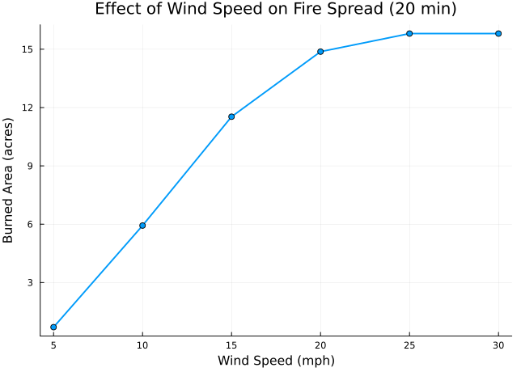

```julia
fuel_table = create_standard_fuel_table(Float64)
wind_speeds = [5, 10, 15, 20, 25, 30]
areas = Float64[]

for ws in wind_speeds
    weather = ConstantWeather{Float64}(
        wind_speed_mph = Float64(ws),
        wind_direction = 270.0,
        M1 = 0.06, M10 = 0.08, M100 = 0.10,
        MLH = 0.60, MLW = 0.90
    )

    state = FireState{Float64}(100, 100, 30.0)
    ignite!(state, 50, 50, 0.0)
    simulate_uniform!(state, 1, fuel_table, weather, 0.0, 0.0, 0.0, 20.0)

    push!(areas, get_burned_area_acres(state))
end

plot(wind_speeds, areas,
    xlabel = "Wind Speed (mph)",
    ylabel = "Burned Area (acres)",
    title = "Effect of Wind Speed on Fire Spread (20 min)",
    linewidth = 2,
    marker = :circle,
    legend = false
)
```

### Fuel Moisture Effects

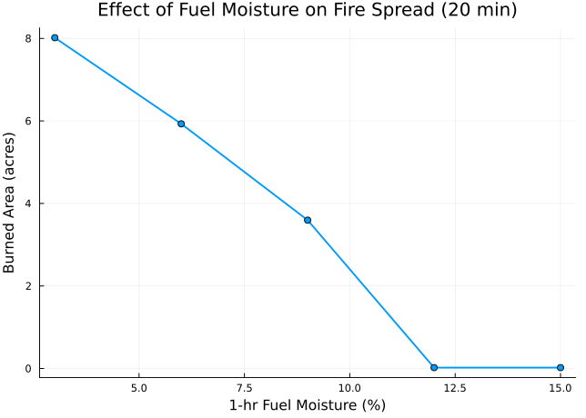

```julia
moisture_levels = [0.03, 0.06, 0.09, 0.12, 0.15]
areas = Float64[]

for m1 in moisture_levels
    weather = ConstantWeather{Float64}(
        wind_speed_mph = 10.0,
        wind_direction = 270.0,
        M1 = m1, M10 = m1 + 0.02, M100 = m1 + 0.04,
        MLH = 0.60, MLW = 0.90
    )

    state = FireState{Float64}(100, 100, 30.0)
    ignite!(state, 50, 50, 0.0)
    simulate_uniform!(state, 1, fuel_table, weather, 0.0, 0.0, 0.0, 20.0)

    push!(areas, get_burned_area_acres(state))
end

plot(moisture_levels .* 100, areas,
    xlabel = "1-hr Fuel Moisture (%)",
    ylabel = "Burned Area (acres)",
    title = "Effect of Fuel Moisture on Fire Spread (20 min)",
    linewidth = 2,
    marker = :circle,
    legend = false
)
```

### Wind Direction

Wind direction is specified in meteorological convention: the direction the wind is blowing **FROM**.

| Direction | Degrees | Fire Spreads To |
| --- | --- | --- |
| North | 0° or 360° | South |
| East | 90° | West |
| South | 180° | North |
| West | 270° | East |

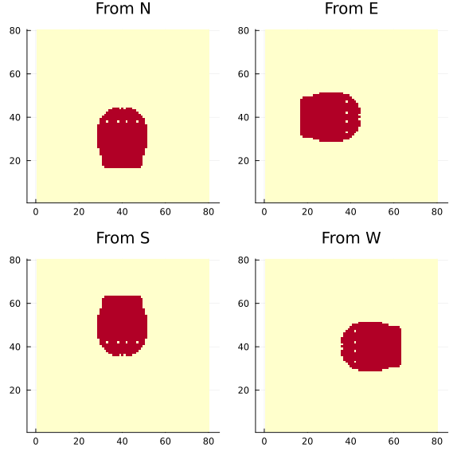

```julia
directions = [0, 90, 180, 270]
labels = ["From N", "From E", "From S", "From W"]
plots_arr = []

for (dir, lbl) in zip(directions, labels)
    weather = ConstantWeather{Float64}(
        wind_speed_mph = 15.0,
        wind_direction = Float64(dir),
        M1 = 0.06, M10 = 0.08, M100 = 0.10,
        MLH = 0.60, MLW = 0.90
    )

    state = FireState{Float64}(80, 80, 30.0)
    ignite!(state, 40, 40, 0.0)
    simulate_uniform!(state, 1, fuel_table, weather, 0.0, 0.0, 0.0, 20.0)

    push!(plots_arr, heatmap(state.burned', title = lbl, color = :YlOrRd,
        aspect_ratio = 1, colorbar = false))
end

plot(plots_arr..., layout = (2, 2), size = (600, 600))
```

## Fire Weather Scenarios

### Typical Conditions

```julia
# Moderate conditions
moderate = ConstantWeather{Float64}(
    wind_speed_mph = 8.0,
    wind_direction = 270.0,
    M1 = 0.08, M10 = 0.10, M100 = 0.12,
    MLH = 0.80, MLW = 1.00
)

# Hot/dry conditions
hot_dry = ConstantWeather{Float64}(
    wind_speed_mph = 15.0,
    wind_direction = 270.0,
    M1 = 0.04, M10 = 0.06, M100 = 0.08,
    MLH = 0.40, MLW = 0.60
)

# Red flag conditions
red_flag = ConstantWeather{Float64}(
    wind_speed_mph = 25.0,
    wind_direction = 45.0,  # Santa Ana direction
    M1 = 0.02, M10 = 0.04, M100 = 0.06,
    MLH = 0.30, MLW = 0.50
)

println("Moderate: $(moderate.wind_speed_20ft) mph, $(moderate.M1*100)% M1")
println("Hot/Dry: $(hot_dry.wind_speed_20ft) mph, $(hot_dry.M1*100)% M1")
println("Red Flag: $(red_flag.wind_speed_20ft) mph, $(red_flag.M1*100)% M1")
```

```
Moderate: 8.0 mph, 8.0% M1
Hot/Dry: 15.0 mph, 4.0% M1
Red Flag: 25.0 mph, 2.0% M1
```

### Comparing Scenarios

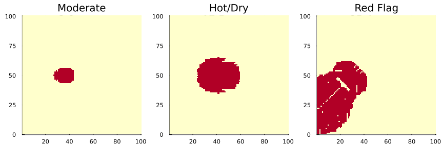

```julia
scenarios = [
    ("Moderate", moderate),
    ("Hot/Dry", hot_dry),
    ("Red Flag", red_flag)
]

plots_arr = []

for (name, weather) in scenarios
    state = FireState{Float64}(100, 100, 30.0)
    ignite!(state, 30, 50, 0.0)
    simulate_uniform!(state, 1, fuel_table, weather, 0.0, 0.0, 0.0, 30.0)

    acres = round(get_burned_area_acres(state), digits=1)
    push!(plots_arr, heatmap(state.burned',
        title = "$name\n$acres acres",
        color = :YlOrRd, aspect_ratio = 1, colorbar = false))
end

plot(plots_arr..., layout = (1, 3), size = (900, 300))
```